# (Ford GoBike System Data)

## by (Amira yousif mohamed)

## Preliminary Wrangling

> This data set includes information about individual rides made in a bike-sharing system covering the greater San Francisco Bay area.

### the structure of your dataset

> There are 174952 Trips in the dataset with 19 features .Most variables are numeric , but the variables bike_share_for_all_trip,user_type are categorical important note i changed the duration trip from seconds to minutes

### features in the dataset will help support investigation into features of interest?

> duration,member_birth_year,member_gender,user_type,start_time,end_time

## First let's investigate the main feature of interest start hour and week days

most of trips starts on thursday which is not a week end and the weekends are the lowest in bike trips i assume students and employees may use them to go to thier work/lectures

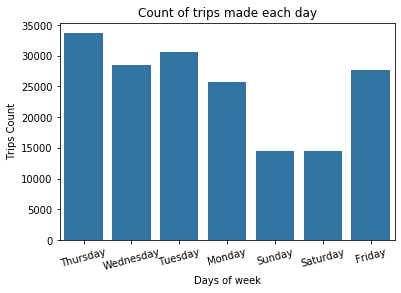

```python
color=sb.color_palette()[0]
sb.countplot(data=bikes,x='week_day',color=color);
plt.xticks(rotation=15);
plt.xlabel('Days of week');
plt.ylabel('Trips Count');
plt.title('Count of trips made each day');
```

in the graph of age distrbution we can see that most trips are taken by users between age of 25-40

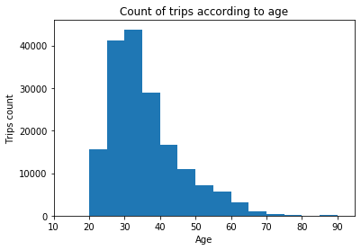

```python
bins=np.arange(0,bikes.age.max()+5,5)
plt.hist(data=bikes,x='age',bins=bins);
plt.xlabel('Age')
plt.xlim(10,95);
plt.ylabel('Trips count');
plt.title('Count of trips according to age');
```

from the age and weekdays chart we can see that thursdays are not the only peak and we can see effect of age on days of trips. but still the week ends have the lowest count of trips

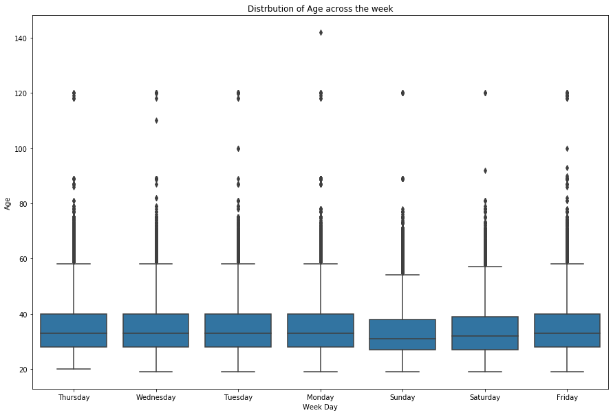

```python
format_boxes(x='week_day',y='age',title='Distrbution of Age across the week',xlabel='Week Day',ylabel='Age')
```

second featur of interset is start hour

most trips are made between hours (5 and 17) and the peak hours are 8 am and 5 pm

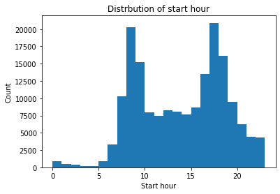

```python
#distrbution of trips by start hours
bins=np.arange(0,bikes.start_hour.max()+1,1)
plt.hist(data=bikes,x='start_hour',bins=bins);
plt.xlabel('Start hour')
plt.ylabel('Count')
plt.title('Distrbution of start hour');
```

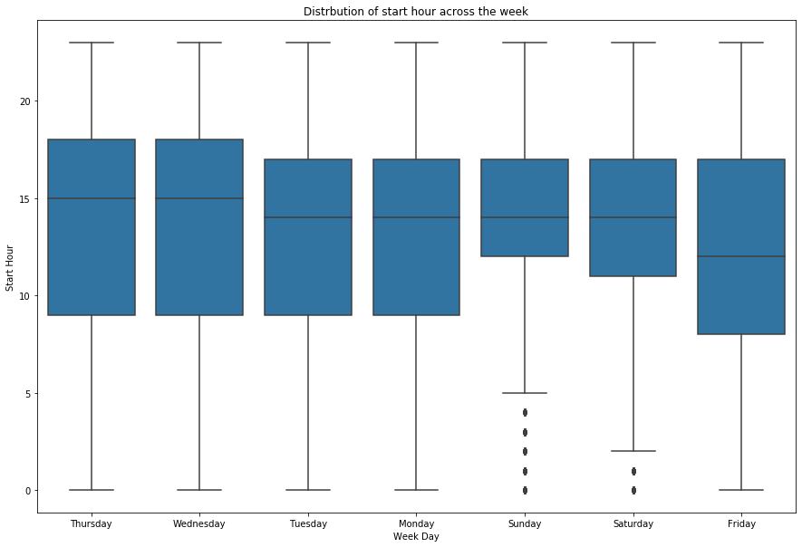

```python
#sb.boxplot(data=bikes,x='week_day',y='start_hour',color=color);
#plt.xlabel('Week Day');
#plt.ylabel('Start hour')
#plt.title('Distrbution of start hour across the week');
format_boxes(x='week_day',y='start_hour',title='Distrbution of start hour across the week',xlabel='Week Day',ylabel='Start Hour')
```

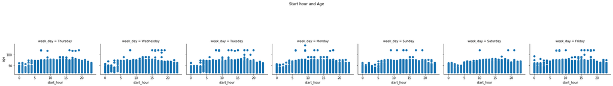

```python
plt.figure(figsize = [15,10])
g = sb.FacetGrid(data = bikes, col = 'week_day', height = 4);
g.map(plt.scatter, 'start_hour','age');
plt.subplots_adjust(top=0.5)
plt.suptitle('Start hour and Age');
```

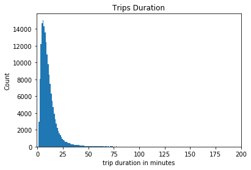

```python
bins=np.arange(0,bikes.duration.max()+1,1);
plt.hist(data=bikes,x='duration',bins=bins);
plt.xlim(-1,200)
plt.xlabel('trip duration in minutes');
plt.ylabel('Count');
#print("Average trip Duration= {}".format(bikes.duration.mean()))
plt.title('Trips Duration');
```

days of trips and duration have a relation to be considered duration of trips gets longer during weekends sunday and saturday this can be due to pepole use bikes for sports or entertainment in the weekend. the trips in the middle of the week is higher in count and shorter in duration which can go with our assumptions that the bikes are used as a transportation method not only for picnics

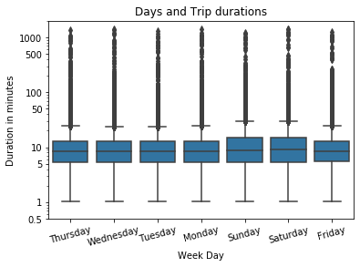

```python
sb.boxplot(data=bikes,x='week_day',y='duration',color=color);
plt.yscale('log')
ticks = [0.5, 1, 5, 10, 50, 100, 500,1000]
# Convert ticks into string values, to be displaye dlong the x-axis
labels = ['{}'.format(v) for v in ticks]
# Apply x-ticks
plt.yticks(ticks, labels);
plt.ylabel('Duration in minutes');
plt.xticks(rotation=15);
plt.xlabel('Week Day');
plt.title('Days and Trip durations');
```

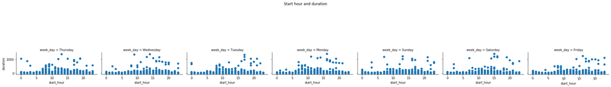

```python
g = sb.FacetGrid(data = bikes, col = 'week_day', size = 4)
g.map(plt.scatter, 'start_hour','duration');
plt.xticks(rotation=15);
plt.subplots_adjust(top=0.4)
plt.suptitle('Start hour and duration');
```

finally to summerize

average trip duration is 11 min and in the week ends average trip is 14 min long

i found that start hour and week days can be affected by age and they also affect each other as starting hour varies according to weekdays

thank you